# 第14回 dplyrとデータ結合

プログラミング演習Ⅰ

佐藤 秀保

sato0035@toyo.jp

## 準備

1. [Posit Cloud](https://posit.cloud/)へ（日本語訳しないことを推奨）
2. 作成済みのプロジェクトをクリック
3. 先週使用のスクリプトをすべて閉じる
4. 新しくスクリプトを作成
5. 作成したスクリプトを保存：名前は「lecture14」
6. ほうきボタンでオブジェクトを削除
7. **library(tidyverse)を実行**
8. **ensyuu13.xlsx、obs.xlsxをアップロード・読込**

授業中のコードはすべてスクリプトに書き実行すること

## データフレームの結合・絞り込み

- dplyrにはデータフレームの結合・絞り込みを目的とした**join系の関数**が複数ある．
  - left_join関数
  - right_join関数
  - inner_join関数
  - full_join関数
  - semi_join関数
  - anti_join関数

### データフレームの結合における「キー」

- キー とは，**結合の際に2つのデータフレームを対応づけるための列**のこと
- 下図のオレンジ色がキー

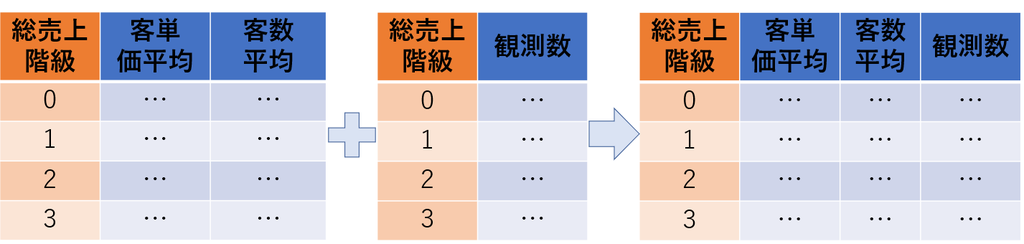

- 「キー」を頼りにすれば，結合するデータフレームの順番がめちゃくちゃでも問題なし

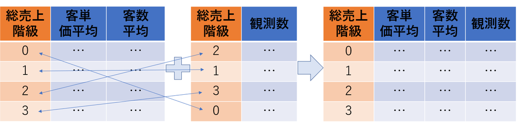

### left_join

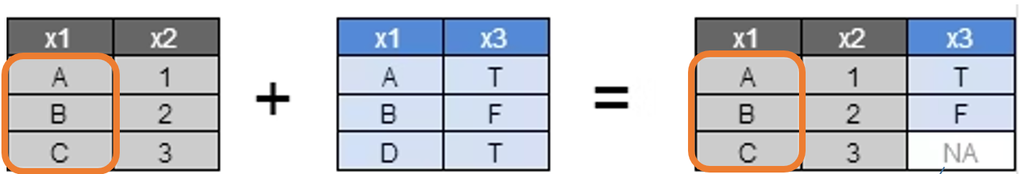

**文法：left_join(左のデータフレーム，右のデータフレーム，by = “キー変数”)**

```r
#エクセルファイル「ensyuu13」,「obs」はを読込済とする
df1 <- ensyuu13 %>%
  left_join(obs, by = "総売上階級")
```

### right_join

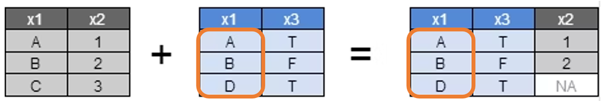

### inner_join

- **双方の**データフレームに共通に存在するキーの行を返す
  - 双方のデータフレームに存在しないキーの行は削除

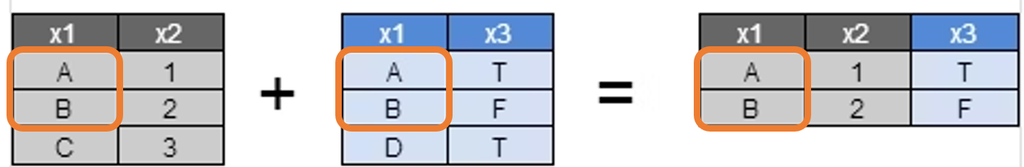

### full_join

- **いずれかの**データフレームに存在するキーの行を返す
  - いずれのデータフレームの行も削除されない

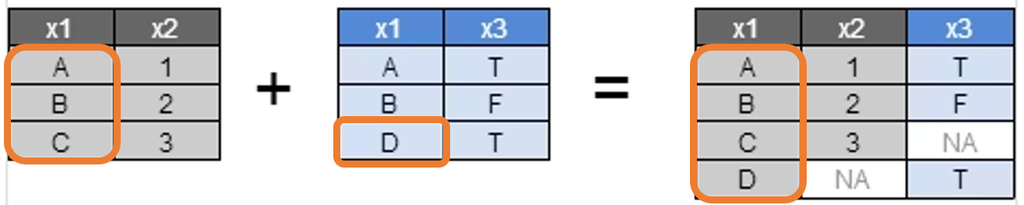

### semi_join

- 結合ではなく絞り込み
- 左のデータフレームから，キーが右のデータフレームにも存在する行を絞り込む

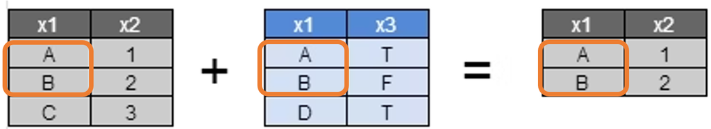

### anti_join

- 結合ではなく絞り込み
- 左のデータフレームから，キーが右のデータフレームに存在しない行を絞り込む

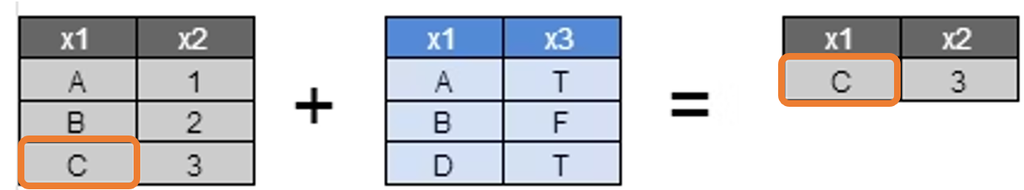

## 演習

1. 「syokudo_data3」を読み込むこと
2. ToyoNet-Aceにある「weather_saitama」エクセルファイルをアップロード&読み込みし，中身を確認せよ．
3. 「日付」をキーとして「syokudo_data3」と「weather_saitama」を結合せよ．ただし，7月のデータは存在しないように結合すること．
4. 「降水量合計」がゼロより大きい場合に1，それ以外の場合には0をとる「雨天ダミー」変数を作成し，「雨天ダミー」の値ごとの「総売上」の平均値を計算したデータフレームを作成せよ．ただし，「総売上」の欠損値はあらかじめ削除のこと．

## エクセルデータの読込方法(Posit Cloud)

- アップロードしたデータを「Import Dataset」から読み込んでいるが，これをコードを書いて実行することも可
  - weather_saitamaの例

  ```r
  #インストール済みのエクセルを読み込むパッケージの読込
  library(readxl)
  #エクセルを読み込み保存
  #ここで代入先の名前を変えることも可能なので，例えば下２つのどちらでもOK
  weather_saitama <- read_excel("weather_saitama.xlsx")
  df_weather <- read_excel("weather_saitama.xlsx")
  #データフレームの中身を確認
  View(weather_saitama)
  ```

## 課題

- ACEの小テスト：「第14回」
- ACEのレポート：「第14回」
  - ローカルに保存したlecture14.Rを提出